# Lab 01 - Hello R

Verity Elliott

01_14_2026

## Load packages and data

```r
library(tidyverse)
library(datasauRus)
data("datasaurus_dozen")
```

## Exercises

### Exercise 1

datasaurus_dozen has 1846 rows and 3 columns: dataset, x and y.

### Exercise 2

Plot chunk:

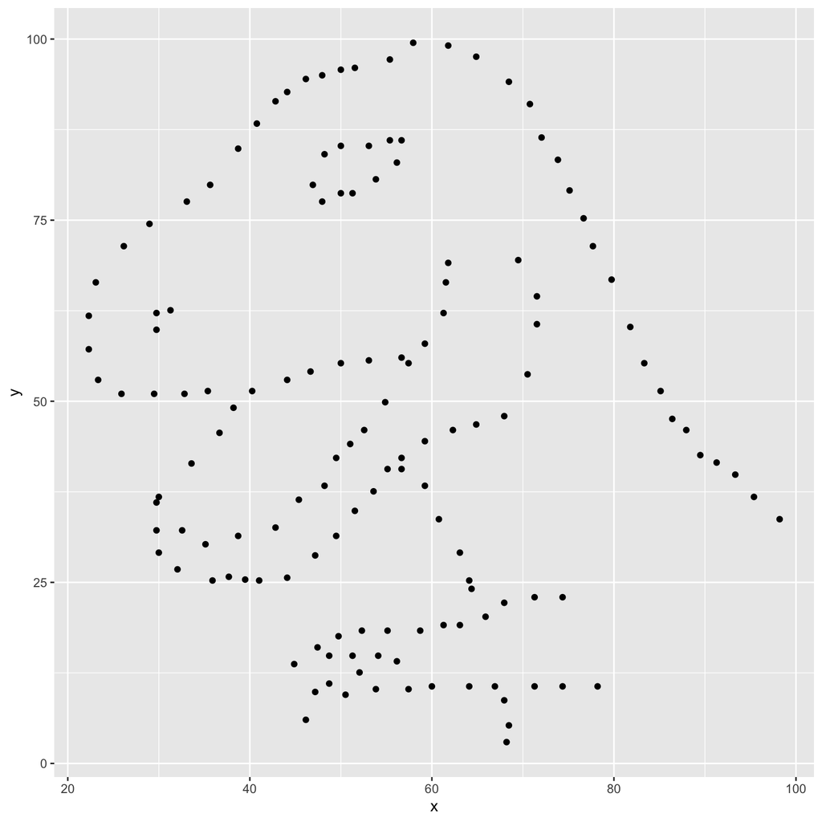

```r
# Filter the datasaurus_dozen dataset for the dino dataset
dino_data <- datasaurus_dozen %>%
  filter(dataset == "dino")

# Plot y vs x
ggplot(dino_data, aes(x = x, y = y)) +
  geom_point()
```

Correlation chunk:

```r
# Calculate the Pearson correlation coefficient between x and y
dino_data %>%
  summarize(r = cor(x, y))
```

```
## # A tibble: 1 × 1
##         r
##     <dbl>
## 1 -0.0645
```

The Pearson correlation coefficient between x and y for the dino dataset is approximately -0.06, which is near zero. This indicates that there is essentially no linear relationship between x and y. This makes sense because correlations measure linear relationships, not the “cool-ness” of the shape datapoints make.

### Exercise 3

Plot chunk:

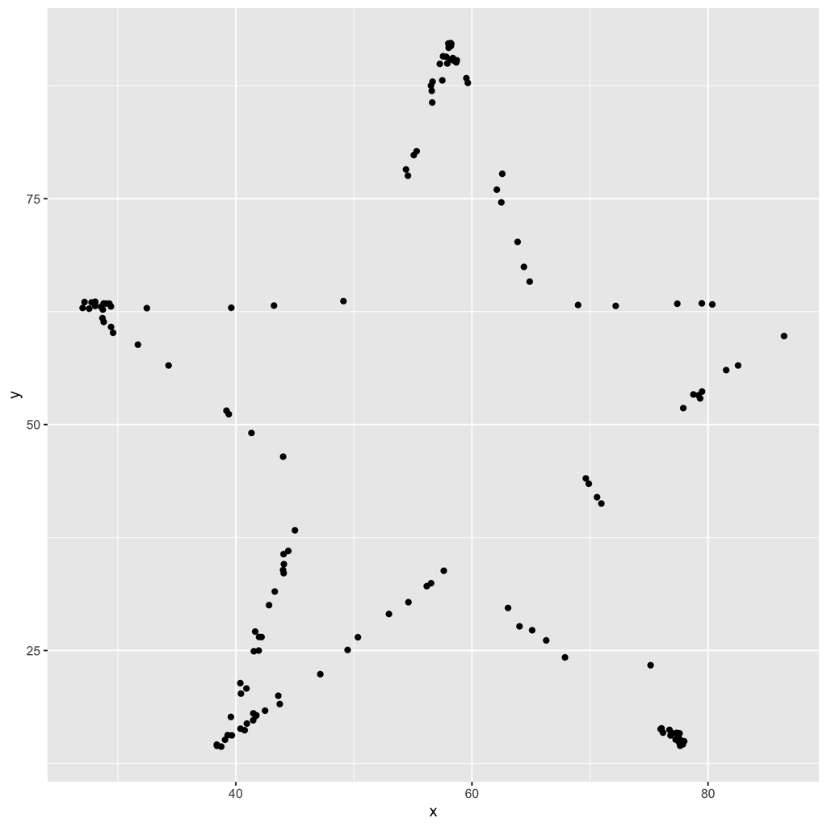

```r
star_data <- datasaurus_dozen %>%
  filter(dataset == "star")

ggplot(star_data, aes(x = x, y = y)) +
  geom_point()
```

Correlation chunk:

```r
star_data %>%
  summarize(r = cor(x, y))
```

```
## # A tibble: 1 × 1
##         r
##     <dbl>
## 1 -0.0630
```

The Pearson correlation coefficient between x and y for the star dataset is approximately -0.06, which is near zero. This again indicate that there is essentially no linear relationship between x and y. Although the scatterplot forms a star shape visually, the points do not follow a linear pattern. This result is much like that of the dino plot: interesting shapes do NOT equal correlation.

### Exercise 4

Plot chunk:

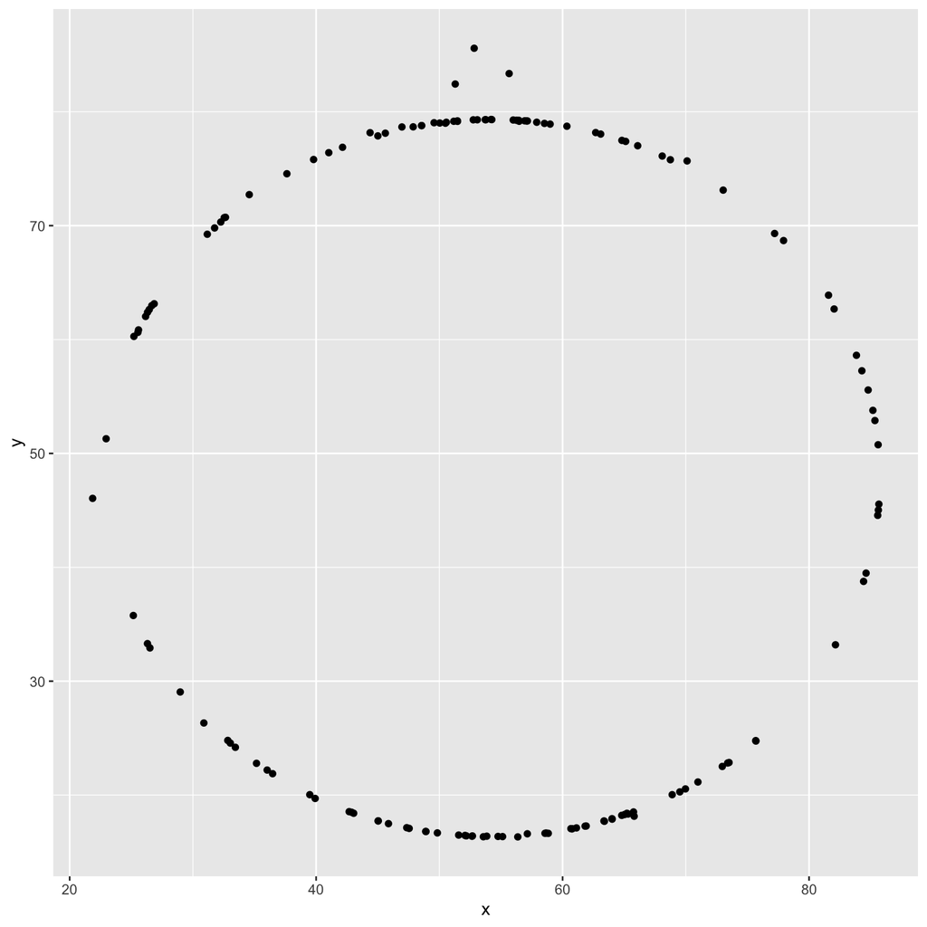

```r
circle_data <- datasaurus_dozen %>%
  filter(dataset == "circle")

ggplot(circle_data, aes(x = x, y = y)) +
  geom_point()
```

Correlation chunk:

```r
circle_data %>%
  summarize(r = cor(x, y))
```

```
## # A tibble: 1 × 1
##         r
##     <dbl>
## 1 -0.0683
```

The Pearson correlation coefficient is approximately -0.07, which is near zero, similar to the dino and star datasets. This indicates that there is essentially no linear relationship between x and y. The datapoints form a distinct circular shape, but there is no linear correlation to speak of. That said, there are three outliers present in this dataset (a feature missing from both the dino and star datasets).

### Exercise 5

Plotting all datasets at once with faceting:

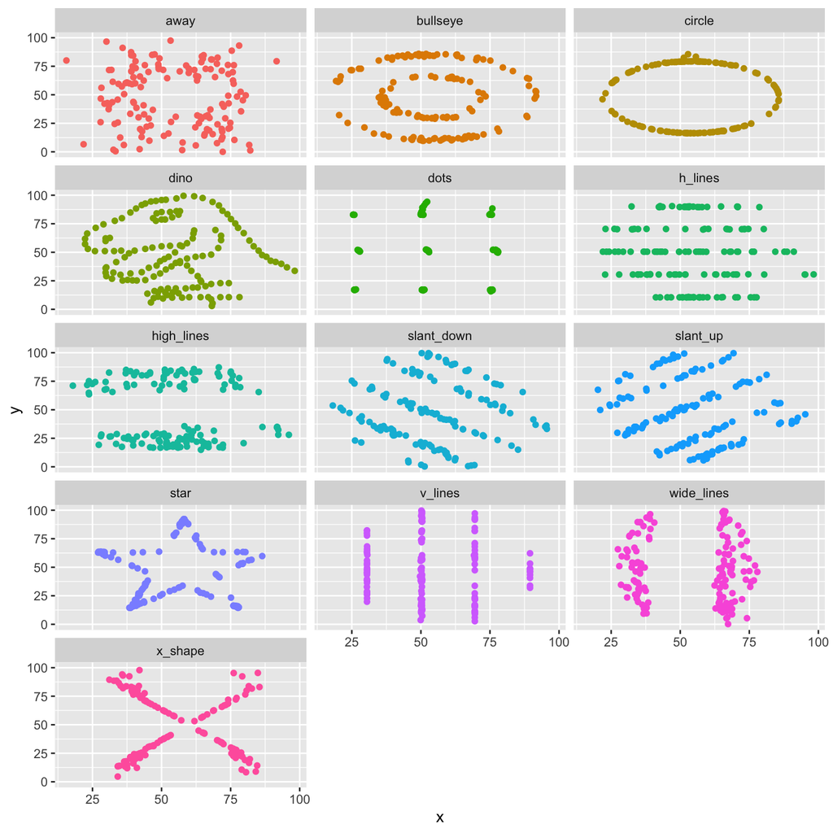

```r
library(ggplot2)
library(dplyr)

ggplot(datasaurus_dozen, aes(x = x, y = y, color = dataset)) +
  geom_point() +
  facet_wrap(~dataset, ncol = 3) +
  theme(legend.position = "none")
```

Calculating correlations for all datasets:

```r
datasaurus_dozen %>%
  group_by(dataset) %>%
  summarize(r = cor(x, y)) %>%
  print(n = 13)
```

```
## # A tibble: 13 × 2
##    dataset          r
##    <chr>        <dbl>
##  1 away       -0.0641
##  2 bullseye   -0.0686
##  3 circle     -0.0683
##  4 dino       -0.0645
##  5 dots       -0.0603
##  6 h_lines    -0.0617
##  7 high_lines -0.0685
##  8 slant_down -0.0690
##  9 slant_up   -0.0686
## 10 star       -0.0630
## 11 v_lines    -0.0694
## 12 wide_lines -0.0666
## 13 x_shape    -0.0656
```

The faceted scatterplots display all datasets from datasaurus_dozen. Each dataset has a unique pattern, yet many of the correlation coefficients are near zero. This illustrates that the Pearson correlation coefficient measures linear relationships only, and can be near zero even when datasets have “cool” (dino) or “boring” (dots) shapes/orientations.